# Project

Shubhaan Saxena and William Payne

3/6/2025

```
## [1] "/Users/shubhaansaxena/OneDrive/Shubhaan_Data/SCU/Winter4/ECON"
```

Step 1: Load Data

Research Question: What is the causal effect of GDP per capita and billionaire counts across countries, and how do other socioeconomic factors such as tax rates, education levels, and price stability affect this relationship?

Hypothesis: Since GDP per capita is a solid indicator of the economic health of a country, there should be a strong causal effect on the number of billionaires. Countries with more economic activity will likely produce a greater number of billionaires than countries that do not.

We will look at gdp per capita, tax rates, CPI, and the percentage of college educated individuals in the country. We will create both linear and non-linear specifications to identify the nature of the relationship.

Step 2:

```
Descriptive Statistics
================================================================================
Statistic      N           Mean                Median             St. Dev.
--------------------------------------------------------------------------------
gdp          2,407 11,725,013,073,028.00 19,910,000,000,000 9,571,410,921,886.00
pop          2,407    512,905,558.00        328,239,523        552,440,082.00
college educ 2,407         67.42               67.00               21.44
cpi          2,407        127.90               117.24              26.56
taxrate      2,407         43.86               39.80               12.05
--------------------------------------------------------------------------------
```

Our table of descriptive statistics includes many of our key variables that we are going to use in regressions. GDP and population will be used in combination in order to observe the GDP per capita. This value is skewed to the left and population is skewed right. The rest of the values are more normal.

Step 3:

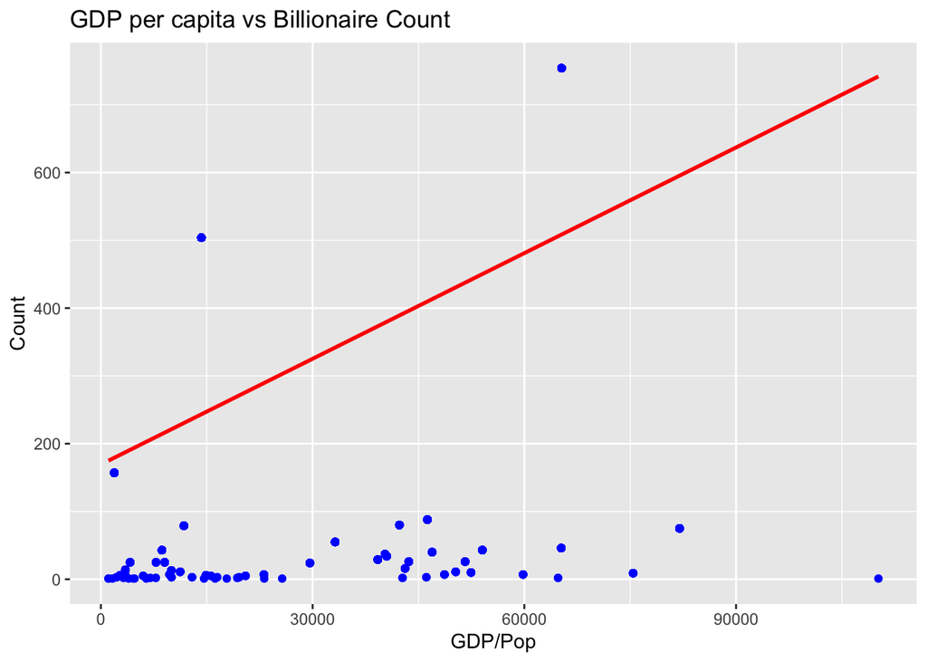

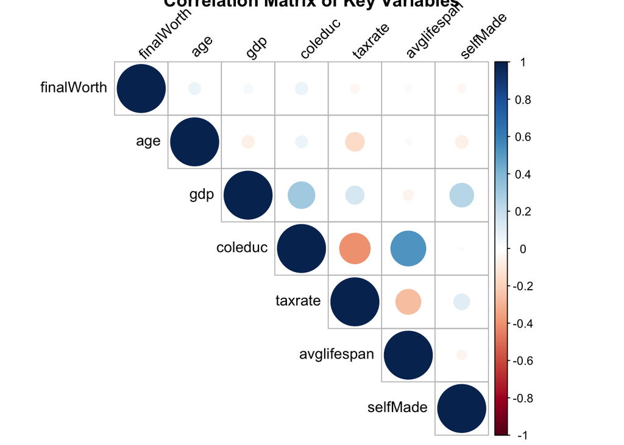

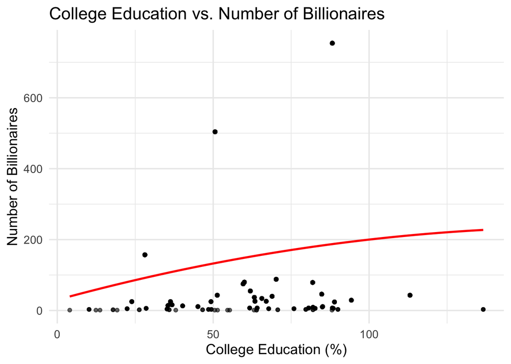

Step 4:

```
Billionaire
==================================================================================================
                                                 Dependent variable:
                    ------------------------------------------------------------------------------
                                                   num_billionaires
                      (1)      (2)      (3)      (4)       (5)       (6)        (7)        (8)
--------------------------------------------------------------------------------------------------
I(gdp/pop)           0.005    0.008    0.007    0.007    -0.013     -0.007     -0.007     -0.008
                    (0.0002) (0.0003) (0.0005) (0.001)   (0.002)   (0.002)    (0.002)    (0.002)

taxrate                       10.524   10.052   10.403   10.382     10.574     28.555     29.355
                             (0.632)  (0.642)  (0.716)   (0.661)   (0.617)    (1.905)    (2.012)

coleduc                                1.943    1.901     4.848     3.766      3.329      7.510
                                      (0.517)  (0.518)   (0.573)   (0.531)    (0.532)    (2.450)

cpi                                             0.654    -1.410     15.215     13.900     14.588
                                               (0.249)   (0.307)   (2.426)    (2.314)    (2.326)

I((gdp/pop)2)                                            0.00000   0.00000    0.00000    0.00000
                                                        (0.00000) (0.00000)  (0.00000)  (0.00000)

I(cpi2)                                                             -0.048     -0.045     -0.046
                                                                   (0.007)    (0.007)    (0.007)

I(taxrate2)                                                                    -0.203     -0.215
                                                                              (0.020)    (0.022)

I(coleduc2)                                                                               -0.031
                                                                                         (0.019)

Constant            169.358  -414.595 -470.559 -587.917 -209.984  -1,580.894 -1,804.220 -2,001.875
                    (8.434)  (32.193) (37.150) (69.964) (82.607)  (207.510)  (198.573)  (231.433)

--------------------------------------------------------------------------------------------------
Observations         2,407    2,407    2,407    2,407     2,407     2,407      2,407      2,407
R2                   0.180    0.280    0.287    0.289     0.351     0.380      0.394      0.396
Adjusted R2          0.180    0.279    0.286    0.288     0.349     0.378      0.392      0.394
Residual Std. Error 281.574  263.935  262.673  262.384   250.760   245.180    242.327    242.042
F Statistic         528.381  467.283  322.574  244.040   259.518   244.811    223.070    196.479
==================================================================================================
Note:                                                                                           NA
```

```
Analysis of Variance Table

Model 1: num_billionaires ~ I(gdp/pop) + taxrate + coleduc + cpi
Model 2: num_billionaires ~ I(gdp/pop) + taxrate + coleduc + cpi + I((gdp/pop)^2) +
    I(cpi^2) + I(taxrate^2) + I(coleduc^2)
  Res.Df       RSS Df Sum of Sq      F    Pr(>F)
1   2402 165366041
2   2398 140485316  4  24880725 106.17 < 2.2e-16 ***
---
Signif. codes:  0 '***' 0.001 '**' 0.01 '*' 0.05 '.' 0.1 ' ' 1
```

```
Linear hypothesis test:
I((gdp/pop)^2) = 0

Model 1: restricted model
Model 2: num_billionaires ~ I(gdp/pop) + taxrate + coleduc + cpi + I((gdp/pop)^2) +
    I(cpi^2) + I(taxrate^2) + I(coleduc^2)

  Res.Df       RSS Df Sum of Sq      F    Pr(>F)
1   2399 148975685
2   2398 140485316  1   8490369 144.93 < 2.2e-16 ***
---
Signif. codes:  0 '***' 0.001 '**' 0.01 '*' 0.05 '.' 0.1 ' ' 1
```

```
Linear hypothesis test:
I(cpi^2) = 0

Model 1: restricted model
Model 2: num_billionaires ~ I(gdp/pop) + taxrate + coleduc + cpi + I((gdp/pop)^2) +
    I(cpi^2) + I(taxrate^2) + I(coleduc^2)

  Res.Df       RSS Df Sum of Sq      F    Pr(>F)
1   2399 146538187
2   2398 140485316  1   6052870 103.32 < 2.2e-16 ***
---
Signif. codes:  0 '***' 0.001 '**' 0.01 '*' 0.05 '.' 0.1 ' ' 1
```

```
Linear hypothesis test:
I(taxrate^2) = 0

Model 1: restricted model
Model 2: num_billionaires ~ I(gdp/pop) + taxrate + coleduc + cpi + I((gdp/pop)^2) +
    I(cpi^2) + I(taxrate^2) + I(coleduc^2)

  Res.Df       RSS Df Sum of Sq      F    Pr(>F)
1   2399 144169965
2   2398 140485316  1   3684649 62.895 3.313e-15 ***
---
Signif. codes:  0 '***' 0.001 '**' 0.01 '*' 0.05 '.' 0.1 ' ' 1
```

```
Linear hypothesis test:
I(coleduc^2) = 0

Model 1: restricted model
Model 2: num_billionaires ~ I(gdp/pop) + taxrate + coleduc + cpi + I((gdp/pop)^2) +
    I(cpi^2) + I(taxrate^2) + I(coleduc^2)

  Res.Df       RSS Df Sum of Sq     F   Pr(>F)
1   2399 140875312
2   2398 140485316  1    389996 6.657 0.009936 **
---
Signif. codes:  0 '***' 0.001 '**' 0.01 '*' 0.05 '.' 0.1 ' ' 1
```

```
Linear hypothesis test:
I(gdp/pop) = 0
I((gdp/pop)^2) = 0

Model 1: restricted model
Model 2: num_billionaires ~ I(gdp/pop) + taxrate + coleduc + cpi + I((gdp/pop)^2) +
    I(cpi^2) + I(taxrate^2) + I(coleduc^2)

  Res.Df       RSS Df Sum of Sq      F    Pr(>F)
1   2400 175568458
2   2398 140485316  2  35083142 299.42 < 2.2e-16 ***
---
Signif. codes:  0 '***' 0.001 '**' 0.01 '*' 0.05 '.' 0.1 ' ' 1
```

```
Linear hypothesis test:
taxrate = 0
I(taxrate^2) = 0

Model 1: restricted model
Model 2: num_billionaires ~ I(gdp/pop) + taxrate + coleduc + cpi + I((gdp/pop)^2) +
    I(cpi^2) + I(taxrate^2) + I(coleduc^2)

  Res.Df       RSS Df Sum of Sq      F    Pr(>F)
1   2400 164907103
2   2398 140485316  2  24421787 208.43 < 2.2e-16 ***
---
Signif. codes:  0 '***' 0.001 '**' 0.01 '*' 0.05 '.' 0.1 ' ' 1
```

```
Linear hypothesis test:
coleduc = 0
I(coleduc^2) = 0

Model 1: restricted model
Model 2: num_billionaires ~ I(gdp/pop) + taxrate + coleduc + cpi + I((gdp/pop)^2) +
    I(cpi^2) + I(taxrate^2) + I(coleduc^2)

  Res.Df       RSS Df Sum of Sq      F    Pr(>F)
1   2400 144444871
2   2398 140485316  2   3959555 33.794 3.362e-15 ***
---
Signif. codes:  0 '***' 0.001 '**' 0.01 '*' 0.05 '.' 0.1 ' ' 1
```

```
Linear hypothesis test:
cpi = 0
I(cpi^2) = 0

Model 1: restricted model
Model 2: num_billionaires ~ I(gdp/pop) + taxrate + coleduc + cpi + I((gdp/pop)^2) +
    I(cpi^2) + I(taxrate^2) + I(coleduc^2)

  Res.Df       RSS Df Sum of Sq      F    Pr(>F)
1   2400 148125552
2   2398 140485316  2   7640236 65.207 < 2.2e-16 ***
---
Signif. codes:  0 '***' 0.001 '**' 0.01 '*' 0.05 '.' 0.1 ' ' 1
```

In this set of regressions, we are analyzing the dependent variable, the number of billionaires in each country. This will be regressed first against GDP per capita. We are also exploring variables like college enrollment in a country, consumer price index, and tax rates. They are converted into quadratic specifications to see if there is a better specification.

This number rises in the next regression after adding tax rates, showing downward OVB. As tax rate rises by one percent, the number of billionaires rises by 10.524 (on avg with all else constant). The next regressor, college enrollment, reflects upward OVB on GDP per capita. As college enrollment rises by one percent, number of billionaires rises by 1.943 on average with all else equal. The final linear regressor is consumer price index, which increases billionaire count by .654 on avg with all else equal for a rise in one unit itself.

The linear variables are all statistically significant after a t-test at the 5 percent significance level. In the fourth regression, the variables are responsible for 28% of the variation in the billionaire count, and have a residual standard error of 262.384.

Therefore, we can say that the F-tests confirm that the relationship between economic factors and billionaire counts is better expressed as quadratic rather than linear.

Step 5:

```
Billionaire
==============================================================================================
                                               Dependent variable:
                    --------------------------------------------------------------------------
                                                 num_billionaires
                       (1)       (2)       (3)      (4)      (5)      (6)      (7)      (8)
----------------------------------------------------------------------------------------------
I(gdp/pop)           0.0004    0.0005    0.0005    0.001    0.001    0.001    0.002    0.001
                    (0.00003) (0.00004) (0.00005) (0.0001) (0.0002) (0.0002) (0.0002) (0.0001)

taxrate                         0.392     0.382    0.378    0.356    0.368    2.328    2.446
                               (0.063)   (0.063)  (0.066)  (0.067)  (0.065)  (0.261)  (0.267)

coleduc                                   0.029    0.034    -0.005   -0.123   -0.173   2.070
                                         (0.046)  (0.046)  (0.051)  (0.044)  (0.042)  (0.179)

cpi                                                0.127    0.160    2.092    2.215    2.185
                                                  (0.037)  (0.038)  (0.153)  (0.153)  (0.166)

I((gdp/pop)2)                                               -0.000   -0.000   -0.000   -0.000
                                                           (0.000)  (0.000)  (0.000)  (0.000)

I(cpi2)                                                              -0.005   -0.006   -0.005
                                                                    (0.0004) (0.0004) (0.0004)

I(taxrate2)                                                                   -0.022   -0.025
                                                                             (0.003)  (0.003)

I(coleduc2)                                                                            -0.016
                                                                                      (0.001)

Constant             30.774    11.846    10.782   -10.434  -16.498  -177.426 -225.863 -294.032
                     (1.585)   (3.288)   (3.527)  (7.327)  (7.112)  (13.873) (16.325) (21.079)

----------------------------------------------------------------------------------------------
Observations           992       992       992      992      992      992      992      992
R2                    0.105     0.136     0.136    0.150    0.155    0.241    0.288    0.406
Adjusted R2           0.104     0.134     0.133    0.147    0.150    0.236    0.283    0.402
Residual Std. Error  26.333    25.886    25.894    25.693   25.639   24.311   23.555   21.515
F Statistic          115.579   77.528    51.786    43.597   36.046   52.020   56.813   84.153
==============================================================================================
Note:                                                                                       NA
```

```
Analysis of Variance Table

Model 1: num_billionaires ~ I(gdp/pop) + taxrate + coleduc + cpi
Model 2: num_billionaires ~ I(gdp/pop) + taxrate + coleduc + cpi + I((gdp/pop)^2) +
    I(cpi^2) + I(taxrate^2) + I(coleduc^2)
  Res.Df    RSS Df Sum of Sq      F    Pr(>F)
1    987 651524
2    983 455013  4    196510 106.13 < 2.2e-16 ***
---
Signif. codes:  0 '***' 0.001 '**' 0.01 '*' 0.05 '.' 0.1 ' ' 1
```

```
Linear hypothesis test:
I((gdp/pop)^2) = 0

Model 1: restricted model
Model 2: num_billionaires ~ I(gdp/pop) + taxrate + coleduc + cpi + I((gdp/pop)^2) +
    I(cpi^2) + I(taxrate^2) + I(coleduc^2)

  Res.Df    RSS Df Sum of Sq      F   Pr(>F)
1    984 458747
2    983 455013  1      3734 8.0669 0.004601 **
---
Signif. codes:  0 '***' 0.001 '**' 0.01 '*' 0.05 '.' 0.1 ' ' 1
```

```
Linear hypothesis test:
I(cpi^2) = 0

Model 1: restricted model
Model 2: num_billionaires ~ I(gdp/pop) + taxrate + coleduc + cpi + I((gdp/pop)^2) +
    I(cpi^2) + I(taxrate^2) + I(coleduc^2)

  Res.Df    RSS Df Sum of Sq      F    Pr(>F)
1    984 520538
2    983 455013  1     65524 141.56 < 2.2e-16 ***
---
Signif. codes:  0 '***' 0.001 '**' 0.01 '*' 0.05 '.' 0.1 ' ' 1
```

```
Linear hypothesis test:
I(taxrate^2) = 0

Model 1: restricted model
Model 2: num_billionaires ~ I(gdp/pop) + taxrate + coleduc + cpi + I((gdp/pop)^2) +
    I(cpi^2) + I(taxrate^2) + I(coleduc^2)

  Res.Df    RSS Df Sum of Sq      F    Pr(>F)
1    984 499388
2    983 455013  1     44375 95.867 < 2.2e-16 ***
---
Signif. codes:  0 '***' 0.001 '**' 0.01 '*' 0.05 '.' 0.1 ' ' 1
```

```
Linear hypothesis test:
I(coleduc^2) = 0

Model 1: restricted model
Model 2: num_billionaires ~ I(gdp/pop) + taxrate + coleduc + cpi + I((gdp/pop)^2) +
    I(cpi^2) + I(taxrate^2) + I(coleduc^2)

  Res.Df    RSS Df Sum of Sq      F    Pr(>F)
1    984 545978
2    983 455013  1     90965 196.52 < 2.2e-16 ***
---
Signif. codes:  0 '***' 0.001 '**' 0.01 '*' 0.05 '.' 0.1 ' ' 1
```

```
Linear hypothesis test:
I(gdp/pop) = 0
I((gdp/pop)^2) = 0

Model 1: restricted model
Model 2: num_billionaires ~ I(gdp/pop) + taxrate + coleduc + cpi + I((gdp/pop)^2) +
    I(cpi^2) + I(taxrate^2) + I(coleduc^2)

  Res.Df    RSS Df Sum of Sq      F    Pr(>F)
1    985 598308
2    983 455013  2    143294 154.78 < 2.2e-16 ***
---
Signif. codes:  0 '***' 0.001 '**' 0.01 '*' 0.05 '.' 0.1 ' ' 1
```

```
Linear hypothesis test:
taxrate = 0
I(taxrate^2) = 0

Model 1: restricted model
Model 2: num_billionaires ~ I(gdp/pop) + taxrate + coleduc + cpi + I((gdp/pop)^2) +
    I(cpi^2) + I(taxrate^2) + I(coleduc^2)

  Res.Df    RSS Df Sum of Sq      F    Pr(>F)
1    985 509972
2    983 455013  2     54959 59.366 < 2.2e-16 ***
---
Signif. codes:  0 '***' 0.001 '**' 0.01 '*' 0.05 '.' 0.1 ' ' 1
```

```
Linear hypothesis test:
coleduc = 0
I(coleduc^2) = 0

Model 1: restricted model
Model 2: num_billionaires ~ I(gdp/pop) + taxrate + coleduc + cpi + I((gdp/pop)^2) +
    I(cpi^2) + I(taxrate^2) + I(coleduc^2)

  Res.Df    RSS Df Sum of Sq      F    Pr(>F)
1    985 553870
2    983 455013  2     98856 106.78 < 2.2e-16 ***
---
Signif. codes:  0 '***' 0.001 '**' 0.01 '*' 0.05 '.' 0.1 ' ' 1
```

```
Linear hypothesis test:
cpi = 0
I(cpi^2) = 0

Model 1: restricted model
Model 2: num_billionaires ~ I(gdp/pop) + taxrate + coleduc + cpi + I((gdp/pop)^2) +
    I(cpi^2) + I(taxrate^2) + I(coleduc^2)

  Res.Df    RSS Df Sum of Sq      F    Pr(>F)
1    985 554922
2    983 455013  2     99909 107.92 < 2.2e-16 ***
---
Signif. codes:  0 '***' 0.001 '**' 0.01 '*' 0.05 '.' 0.1 ' ' 1
```

Here is an alternative subset with the same regressions. The complete dataset involved outliers (the USA, China, and India) that all had over 150 billionaires in the country. These values were influencing the regressions greatly and leading them to not show the complete causal relationship between our variables of interest. The dataset ‘bill_small’ limits the billionaire count to 150. The same regressions were re-run.

F-tests strongly support the inclusion of quadratic terms. The comparison between the linear-only model and the full quadratic model yields highly significant results (p < 2.2e-16). When testing individual quadratic terms and joint significance of linear and squared terms together, all factors show statistical significance.

Step 6: Internal and External Validity

Regarding the external validity of this dataset and our regression analysis – these results can be generalized to the whole population because we are studying the whole population of billionaires. There are obviously not many in the world and this dataset includes all of them. Additionally, this data is from 2023, so there is likely not a large difference in the population now than from two years ago. There are likely not any regulatory differences nor differences in enviornment between now and 2023. One technology that might have affected the real-world population is the development of artificial intelligence, but by this point it was already in use.

Internal validity: In our regressions, there are likely omitted variables that are correlated with our explanatory variables and affect the outcome. There are many factors that contribute to the number of billionaires in a country, and it would be difficult to analyze all of them. One, however, is the level of foreign direct investment (FDI) of a country. There is a possible positive correlation because FDI helps productivity, and FDI has a multitude of ways it could influence billionaire count. Entrepreneurs can benefit by the increased capital and personnel from FDI, pushing them into billionaire status.

We have tried to account for functional form by including quadratic terms in our regressions. These have returned statistically signifcant coefficients and more favorable measures of fit. Additionally, these regressions are also statistically significant using F-Tests. Our question and hypothesis asks for the number (continuous), so there is no benefit to using a discrete dependent variable.

Much information about billionaires, their net worth, and their industries are available to the public. Unless they manage to have their true net worth hidden (by some kind of weird, illegal means), then there are no worries about intentionally false reports. The data was also not collected by survey and country information like GDP and population is public as well.

There is statistically significant evidence that GDP per capita has a causal relationship with billionaire count. However, billionaires are continuously investing in businesses, employing people, and have other means of economic influence. These facets of the economy can lead to higher productivity and GDP per capita.